# Assignment 2: Differential expression analysis and investigation of biological effects of SAHA treatment of diabetic human aortic endothelial cells

**Name:** Michael Apostolides

# Download expression data from GEO

# INTRODUCTION

The dataset is from [GEO GSE77108](https://www.ncbi.nlm.nih.gov/geo/query/acc.cgi?acc=GSE77108)(Rafehi et al. 2017), and selects one of several treatment analysis in this paper. This paper corresponds to the GEO dataset with ID GSE77108. The treatment selected is SAHA treatment of human aortic endothelial cells obtained from a diabetic individual (dHAECs) line as compared to control DMSO treatment of those same dHAECs. My workflow begins with the RNAseq read counts provided by the authors, which were obtained using the “Counts” feature of the STAR RNAseq aligner(Rafehi et al. 2017).  
Normalization has already been done by the authors using the HPRT1 housekeeping gene(Rafehi et al. 2017). However, I have gone ahead and normalized the data again anyway using TMM:

## TMM normalization

```r
#APPLYING TMM NORMALIZATION TO THE DATASET
filtered_data_matrix <- as.matrix(diabetic.SAHA.DMSO.filtered[,2:ncol(diabetic.SAHA.DMSO)])
rownames(filtered_data_matrix) <- rownames(diabetic.SAHA.DMSO.filtered)
d = DGEList(counts=filtered_data_matrix, group=samples$treatment)
d = calcNormFactors(d)

final.df <- cpm(d)
final.df.log2 <- log2(cpm(d))
# add hgnc symbols as first column
final.df.log2 <-cbind.data.frame(diabetic.SAHA.DMSO.filtered[,1],final.df.log2, stringsAsFactors = FALSE)
colnames(final.df.log2)[1] <- "hgnc_symbol"

# The reason we were getting -Inf values is because the values were "0" prior to log2 transformation
#remove values which have -Inf as values in matrix
final.df <- final.df.log2
final.df[final.df== -Inf] <- 0
```

# Differential Gene Expression

I used the Benjamini-Hockberg adjustment method. I initially tried the Bonferroni method, but it proved to be too stringent. Some of the pro-inflammantory genes that were deemed “significant” in the (Rafehi et al. 2017) paper were filtered out with Bonferroni, so I used the Benjamini-Hockberg adjustment method instead.

I used the epiriical Bayes method to compute differential expression, with trend=TRUE set to specify RNAseq data.

```r
#CREATE DATA MATRIX

model_design <- model.matrix(~ samples$treatment)
expressionMatrix <- as.matrix(final.df[,2:ncol(final.df)])
#USE LIMMA PACKAGE
minimalSet <- ExpressionSet(assayData=expressionMatrix)
fit <- lmFit(minimalSet, model_design)
#Apply empircal Bayes to compute differential expression
fit2 <- eBayes(fit,trend=TRUE)

adjust.method = "BH"
#adjust.method="bonferroni"
topfit <- topTable(fit2,
                   sort.by="none",
                   coef=ncol(model_design),
                   adjust.method = adjust.method,
                   number = nrow(expressionMatrix))

topfit <-cbind.data.frame(diabetic.SAHA.DMSO.filtered[,1],topfit, stringsAsFactors = FALSE)
colnames(topfit)[1] <- "hgnc_symbol"
```

## Plot of differentially expressed genes

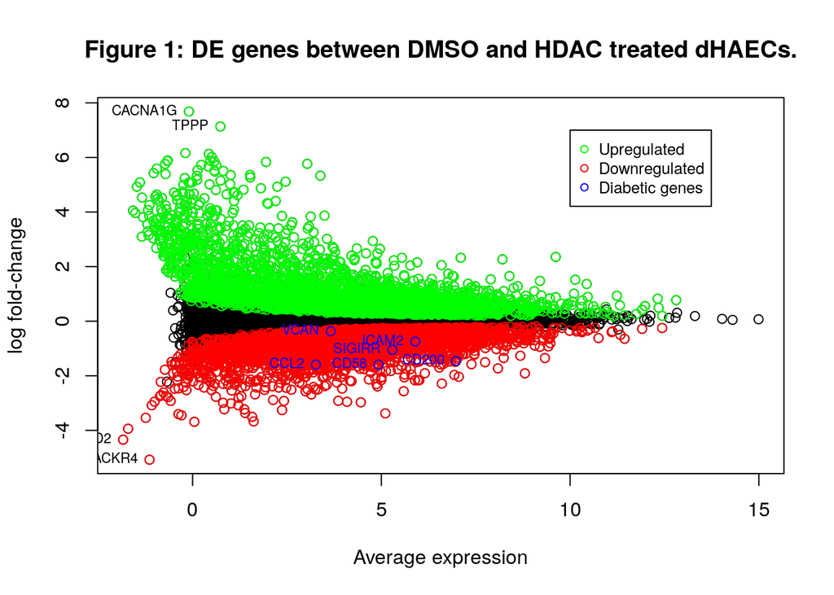

```r
title <- "Figure 1: DE genes between DMSO and HDAC treated dHAECs."
plot(topfit$AveExpr,topfit$logFC, main=title, xlab= "Average expression", ylab= "log fold-change")
pval <- 0.05
# create up and down indices using pval cutoff and logFC
down.index <- which((topfit$adj.P.Val < pval) & (topfit$logFC < 0))
up.index <- which((topfit$adj.P.Val < pval) & (topfit$logFC > 0))
# colour points accordingly
points(topfit$AveExpr[up.index], topfit$logFC[up.index], col = "green")
points(topfit$AveExpr[down.index], topfit$logFC[down.index], col = "red")
#diabetic inflammatory genes investigated in paper
D.inflamm.genes <- c("VCAN", "CD58", "CD200",  "SIGIRR", "CCL2", "ICAM2")
D.inflamm.index <- which(topfit$hgnc_symbol %in% D.inflamm.genes )
points(topfit$AveExpr[D.inflamm.index], topfit$logFC[D.inflamm.index], col = "blue")
text(topfit$AveExpr[D.inflamm.index], topfit$logFC[D.inflamm.index], labels=D.inflamm.genes, cex= 0.7, pos=2, col = "blue")

num.genes <- 2
# Highest logFC genes
top.up.genes <- head(topfit[order(topfit$logFC, decreasing = TRUE),], num.genes)$hgnc_symbol
top.up.genes.idx <- which(topfit$hgnc_symbol %in% top.up.genes )
labels.up <- topfit$hgnc_symbol[top.up.genes.idx]
text(topfit$AveExpr[top.up.genes.idx], topfit$logFC[top.up.genes.idx], labels=labels.up, cex= 0.7, pos=2)
#Lowest logFC genes
top.down.genes <- head(topfit[order(topfit$logFC, decreasing = FALSE),], num.genes)$hgnc_symbol
top.down.genes.idx <- which(topfit$hgnc_symbol %in% top.down.genes )
labels.down <- topfit$hgnc_symbol[top.down.genes.idx]
text(topfit$AveExpr[top.down.genes.idx], topfit$logFC[top.down.genes.idx], labels=labels.down, cex= 0.7, pos=2)
# LEGEND
legend(10, 7,legend=c("Upregulated", "Downregulated", "Diabetic genes"),col=c("green", "red" ,"blue"), pch=1, cex=0.8)
```

## Counts of DE genes

I used a threshold of 0.05 cutoff for the adjusted p-value. My DE results returened a total of 6600/13175 genes deemed significantly differentially expressed. Of these, 3291 were significantly upregulated and 3309 significantly downregulated. I include labels for diabetic genes, as well as the top 2 upregulated and downregulated genes (Figure 1).

# Clustering of top hits using heatmap

The heatmap shows that DMSO and SAHA treated are clustering separately.

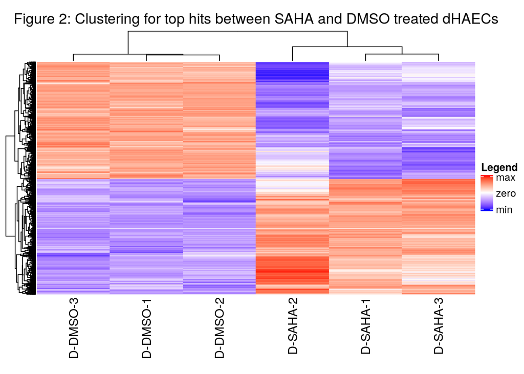

```r
#Make HEATMAP ==> TAKES LONG TIME, ONLY PRINT HEATMAP AT VERY END
# get significant indices
significant.index <- which((topfit$adj.P.Val < pval))
heatmap_matrix <- final.df[significant.index, 2:ncol(final.df)]
#heatmap_matrix <- head(heatmap_matrix, 10)

heatmap_matrix <- t(scale(t(heatmap_matrix)))
heatmap_col = colorRamp2(c(min(heatmap_matrix), 0, max(heatmap_matrix)), c("blue", "white", "red"))

current_heatmap <- Heatmap(as.matrix(heatmap_matrix),
                               column_title = "Figure 2: Clustering for top hits between SAHA and DMSO treated dHAECs",
                               show_row_dend = TRUE,
                               show_column_dend = TRUE,
                               col=heatmap_col,
                               show_column_names = TRUE,
                               show_row_names = FALSE,
                               show_heatmap_legend = TRUE
                               ,

heatmap_legend_param = list(
        title = "Legend", at = c(-2, 0, 2), labels = c("min", "zero", "max")
    )

)

current_heatmap
```

# Investigate data (using top hits)

```r
pval <- 0.05

#ALL
significant.index <- which((topfit$adj.P.Val < pval))
sign.genes.all <- topfit[significant.index,]$hgnc_symbol
#QUERY GPROFILER
gprofiler.stash <- "gprofiler.ALL.results.rds"
if(file.exists(gprofiler.stash)){
  gprofiler.results <- readRDS(gprofiler.stash)
} else {
  gprofiler.results <- gost(sign.genes.all, organism = "hsapiens" )
  saveRDS(gprofiler.results, gprofiler.stash)
}
gprofiler.results <- gprofiler.results$result

#UPREGULATED
up.index <- which((topfit$adj.P.Val < pval) & (topfit$logFC > 0))
sign.genes.up <- topfit[up.index,]$hgnc_symbol
#QUERY GPROFILER
gprofiler.stash <- "gprofiler.UPREGULATED.results.rds"
if(file.exists(gprofiler.stash)){
  gprofiler.results.up <- readRDS(gprofiler.stash)
} else {
  gprofiler.results.up <- gost(sign.genes.up, organism = "hsapiens" )
  saveRDS(gprofiler.results.up, gprofiler.stash)
}
gprofiler.results.up <- gprofiler.results.up$result


#DOWNREGULATED
down.index <- which((topfit$adj.P.Val < pval) & (topfit$logFC < 0))
sign.genes.down <- topfit[down.index,]$hgnc_symbol

#QUERY GPROFILER
gprofiler.stash <- "gprofiler.DOWNREGULATED.results.rds"
if(file.exists(gprofiler.stash)){
  gprofiler.results.down <- readRDS(gprofiler.stash)
} else {
  gprofiler.results.down <- gost(sign.genes.down, organism = "hsapiens" )
  saveRDS(gprofiler.results.down, gprofiler.stash)
}
gprofiler.results.down <- gprofiler.results.down$result

#WNT term counts for unfiltered results
wnt <- gprofiler.results[grep("Wnt|wnt", gprofiler.results$term_name),]
wnt.up <- gprofiler.results.up[grep("Wnt|wnt", gprofiler.results.up$term_name),]
wnt.down <- gprofiler.results.down[grep("Wnt|wnt", gprofiler.results.down$term_name),]
```

# Interpretation of top DE gene hits

## My results support conclusions of original paper

In the original (Rafehi et al. 2017) paper, they showed that SAHA reversed expression of EP300 target genes in dHAECs. They selected candidate genes VCAN, CD58, CD200, SIGIRR, CCL2, and ICAM2 which are upregulated in dHAECs, and suppressed by EP300 knockdown (Rafehi et al. 2017). They showed that exposure of dHAECs to SAHA reduced the expression of these 6 upregulated genes, concluding that SAHA reverses the upregulation of pro-inflammatory genes in dHAECs (Rafehi et al. 2017).

In my investigation of the same data, I also looked at these 6 genes, and showed that their expression is significantly decreased in dHAECs treated with SAHA (Figure 1), which is consistent with the results obtained by the paper.

## Search of literature for 4 top gene hits

Expression of CACNA1G was highly increased upon treatment of neural induced human adipose tissue-derived mesenchymal stem cells (NI-hADSCs) with HDAC inhibitor (Sujeong Jang 2018a). Binding of the TPPP/p25 complex to HDAC6 is know to inhibit HDAC6 deacetylating function in HeLa cells (d’Ydewalle, Bogaert, and Van Den Bosch 2012). Since An increase in both CACNA1G and TPPP are seen in our SAHA-treated sample, this is consistent with HDAC inhibition.

# Interpretation of gprofiler gene set results

## Method and annotation data

I used gprofiler, using the “gprofiler2” R package. I used this meta-database because it has a corresponding R package to fetch data, and we have gained familiarity with it in class. It contains the “GO:BP” dataset (Biological Process), which is the data source which I found most useful for understanding the effect of SAHA on the cell’s biology. It returns the most results related to biological function/pathways. I also included all other data sources provided by gprofiler.

The version of the annotation data are those which gprofiler uses on the date of compilation of this notebook, since the “gprofiler2” R package uses the same annotation data as the g:profiler web application

I used the p-value of 0.05 as the threshold for gene sets, and subsequently filtered for smaller term size and more stringent p-value.

The number of genesets for total, upregulated and downregulated gene queries can be seen in Table 1. The column “Total.Counts” corresponds to all terms returned with p_value=0.05, and “Filtered.Counts” correspond to p_value=0.00005, and term.size=500 (Table 1).

I used the “Filtered.Counts” results to look at higher confidence and more meaningful gene sets. I will refer to the **unfiltered** (p_value=0.05) and **filtered** (p_value=0.00005, and term.size=500) gprofiler results from this point onwards.

## Gprofiler result tables

Table 1: Gene set counts for gprofiler results

| Query | Total.Counts | Filtered.Counts |
| --- | --- | --- |
| Total | 2251 | 74 |
| Upregulated | 1426 | 18 |
| Downregulated | 2036 | 168 |

Table 2: Comparison of top filtered terms for total, upregulated and downregulated gene queries

| Total | Upregulated | Downregulated |
| --- | --- | --- |
| Retinoblastoma Gene in Cancer | small GTPase binding | DNA replication |
| Cell cycle | cell cortex | Retinoblastoma Gene in Cancer |
| Mitotic G1-G1/S phases | Rab GTPase binding | chromosome, centromeric region |
| S Phase | Ras GTPase binding | Cell Cycle Checkpoints |
| ATPase activity | site of polarized growth | chromosome segregation |
| regulation of mitotic cell cycle phase transition | growth cone | DNA-dependent DNA replication |
| ATPase activity, coupled | vacuolar membrane | chromosomal region |
| DNA replication | protein localization to cell periphery | condensed chromosome |
| microtubule | axonogenesis | S Phase |
| Cell Cycle | Lysosome | kinetochore |
| regulation of cell cycle phase transition | lysosomal membrane | ATPase activity |
| signal transduction by p53 class mediator | lytic vacuole membrane | sister chromatid segregation |
| cell cycle G2/M phase transition | canonical Wnt signaling pathway | DNA Replication |
| response to oxygen levels | actin binding | Cell cycle |
| chromosome, centromeric region | Autophagy - animal | ATPase activity, coupled |

## Comparison of filtered gprofiler results for total, upregulated and downregulated genes

I created a table with the top 15 terms for the filtered gprofiler results specified above to look at the most significant terms in total, upregulated and downregulated queries (Table 2). Some interesting patterns can be seen.

**Downregulated**: The top downregulated terms correspond almost exclusively to DNA replication, cell cycle checkpoint, and chromosome segregation gene sets. Retinoblastoma Gene in Cancer is the second hit. This seems to have a lot in common with “total” query.

In the following 2 sections, I discuss these results. The original paper (Rafehi et al. 2017) does not discuss all of these these, since they were focusing on pro-inflammatory genes in dHAECs.

## Retinoblastoma, cell cycle effects

HDAC inhibitors are known to have effects on retinoblastoma cell lines, inducing growth arrest and apoptosis. (Poulaki et al. 2009). Retinoblastoma is related to the top, and second hits of, “Total” and “Downregulated” genes, respectively (Table 2). Additionally, HDAC inhibitors are known to interfere with progression of the cell cycle (G1 arrest) in human cancers in general (YOUNG BAE KIM 2000). This is consistent with the numerous cell-cycle related hits in both the “Total” and “Downregulated” top gene sets (Table 2). Additionally, the original (Rafehi et al. 2017) paper found that the cell cycle was more likely to be suppressed in dHAECs based on integration of RNA-seq and ChIP-seq data. My top 15 hits also show this pattern (Table 2, columns 1 and 3).

## Wnt pathway, Ras and neuronal development effects are seen

I investigated the effect of HDAC inhibitors on the Wnt signalling pathway. In the (Götze et al. 2014) paper, they show that SAHA attenuates proliferation and induces apoptosis in Wnt-activated colorectal carcinoma cell lines. In the (Sujeong Jang 2018b) paper, they show that expression of most of the Wnt-related genes they were investigating were highly increased following treatment with HDAC inhibitors.

The unfiltered gprofiler results for Wnt terms have counts of total(8), upregulated(7) and downregulated(0) for the unfiltered gprofiler results. When looking at top 15 filtered results, we see Wnt signaling come up only in the upregulated query (Table 2)

Interestingly, two of the Wnt-related “upregulated” gene sets in unfiltered results are termed “negative regulation of canonical Wnt signaling pathway”, and “negative regulation of Wnt signaling pathway”. It is possible that in diabetic endothelial cells, upregulation of certain genes negatively regulates the Wnt signalling pathway.

We also see “Ras/Rab GTPase” terms in the filtered upregulated gene sets. In the (Kobayashi 2006) study, they show that the HDAC inhibitor FK228 suppresses the Ras-MAPK signalling pathway, which supports this finding.

Overall, these results are consistent with what is found about Wnt signalling, neuronal differentiation, and Ras signalling in relation to HDAC inhibitors in the literature(Götze et al. 2014), (Sujeong Jang 2018b).

# Summary

These results suggest that the authors of the (Rafehi et al. 2017) paper selectively looked at pro-inflammatory genes in diabetes, since many biological processes are affected by SAHA which are unrelated to diabetes. The literature supports similar pathways and processes being affected by SAHA in various cancers. The (Rafehi et al. 2017) proposes that their study of SAHA’s effects can be used as a prediction for novel therapies for existing disease. The results of my analysis of the (Rafehi et al. 2017) paper’s data replicates their results with respect to pro-inflammatory diabetes genes. I also find support in the for top hits of genes and pathways found in my analysis of this dataset.

# R package references

GEOmetadb https://www.bioconductor.org/packages/release/bioc/html/GEOmetadb.html

edgeR https://bioconductor.org/packages/release/bioc/html/edgeR.html

biomaRt https://bioconductor.org/packages/release/bioc/html/biomaRt.html

tidyr https://cran.r-project.org/web/packages/tidyr/index.html

dplyr https://cran.r-project.org/web/packages/dplyr/index.html

ComplexHeatmap https://bioconductor.org/packages/release/bioc/html/ComplexHeatmap.html

circlize https://cran.r-project.org/web/packages/circlize/index.html

gprofiler2 https://cran.r-project.org/web/packages/gprofiler2/index.html\

stringr https://cran.r-project.org/web/packages/stringr/stringr.pdf\

kableExtra https://cran.r-project.org/web/packages/kableExtra/index.html\

# Paper references

Chemudupati, Mahesh, Anna C. Smith, Robert J. Fillinger, Adam D. Kenney, Lizhi Zhang, Ashley Zani, Shan-Lu Liu, Matthew Z. Anderson, Amit Sharma, and Jacob S. Yount. 2020. “Short Chain Fatty Acid Butyrate Promotes Virus Infection by Repressing Interferon Stimulated Genes.” *bioRxiv*. Cold Spring Harbor Laboratory. https://doi.org/10.1101/2020.02.04.934919.

d’Ydewalle, Constantin, Elke Bogaert, and Ludo Van Den Bosch. 2012. “HDAC6 at the Intersection of Neuroprotection and Neurodegeneration.” *Traffic* 13 (6): 771–79. https://doi.org/10.1111/j.1600-0854.2012.01347.x.

Götze, Silke, Monique Coersmeyer, Oliver Mueller, and Sonja Sievers. 2014. “Histone Deacetylase Inhibitors Induce Attenuation of Wnt Signaling and Tcf7l2 Depletion in Colorectal Carcinoma Cells.” *International Journal of Oncology* 45 4: 1715–23. https://www.ncbi.nlm.nih.gov/pubmed/25050608.

Kobayashi, Ohtsuki, Y. 2006. “Histone Deacetylase Inhibitor Fk228 Suppresses the Ras–Map Kinase Signaling Pathway by Upregulating Rap1 and Induces Apoptosis in Malignant Melanoma.” *Oncogene* 25 (6): 512–24. https://doi.org/10.1038/sj.onc.1209072.

Poulaki, Vassiliki, Constantine S. Mitsiades, Vassiliki Kotoula, Joseph Negri, Ciaran McMullan, Joan W. Miller, Paul A. Marks, and Nicholas Mitsiades. 2009. “Molecular Sequelae of Histone Deacetylase Inhibition in Human Retinoblastoma Cell Lines: Clinical Implications.” *Investigative Ophthalmology & Visual Science* 50 (9): 4072–9. https://doi.org/10.1167/iovs.09-3517.

Rafehi, Haloom, Antony Kaspi, Mark Ziemann, Jun Okabe, Tom C. Karagiannis, and Assam El-Osta. 2017. “Systems Approach to the Pharmacological Actions of Hdac Inhibitors Reveals Ep300 Activities and Convergent Mechanisms of Regulation in Diabetes.” *Epigenetics* 12 (11). Taylor & Francis: 991–1003. https://doi.org/10.1080/15592294.2017.1371892.

Sujeong Jang, Han-Seong Jeong. 2018a. “Data for the Effect of Histone Deacetylase Inhibitors on Voltage- and Ligand-Gated Ion Channel Gene Expression in Neurogenic Induced-Human Adipose Tissue-Derived Mesenchymal Stem Cells.” *Data in Brief* 17: 1314–9. https://doi.org/10.1016/j.dib.2018.02.058 .

———. 2018b. “Histone Deacetylase Inhibition-Mediated Neuronal Differentiation via the Wnt Signaling Pathway in Human Adipose Tissue-Derived Mesenchymal Stem Cells.” *Neuroscience Letters* 668: 24–30. https://doi.org/10.1016/j.neulet.2018.01.006 .

Venugopal Thayanithy, Aaron L. Sarver, ChangWon Park, and Subbaya Subramanian. 2012. “Combinatorial Treatment of Dna and Chromatin-Modifying Drugs Cause Cell Death in Human and Canine Osteosarcoma Cell Lines.” *PLoS One*. https://www.ncbi.nlm.nih.gov/pmc/articles/PMC3434163/ .

YOUNG BAE KIM, MINORU YOSNIDA, SE WON KI. 2000. “Mechanism of Cell Cycle Arrest Caused by Histone Deacetylase Inhibitors in Human Carcinoma Cells.” *The Journal of Antibiotics* 53 (10): 1191–1200. https://doi.org/10.7164/antibiotics.53.1191.